# Reproducible research: Peer Assessment 1

## What is the average daily activity pattern?

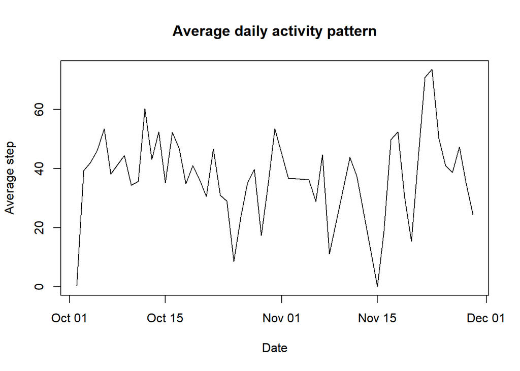

```r
#compute mean and median of steps
MeanMedianPerDays <- DSwithoutNA %>%
   group_by( date) %>%
   arrange( date, steps) %>%
   select( steps, date) %>%
   summarise ( "mean" = mean( steps,na.rm = TRUE), "Median"= median( steps, na.rm = TRUE))


# plot average daily activity pattern
plot( x= MeanMedianPerDays$date, y= MeanMedianPerDays$mean, type="l", xlab = "Date", ylab = "Average step", main = "Average daily activity pattern")
```

1. Make a time series plot (i.e. type=“l”) of the 5-minute interval (x-axis) and the average number of steps taken, averaged across all days (y-axis)

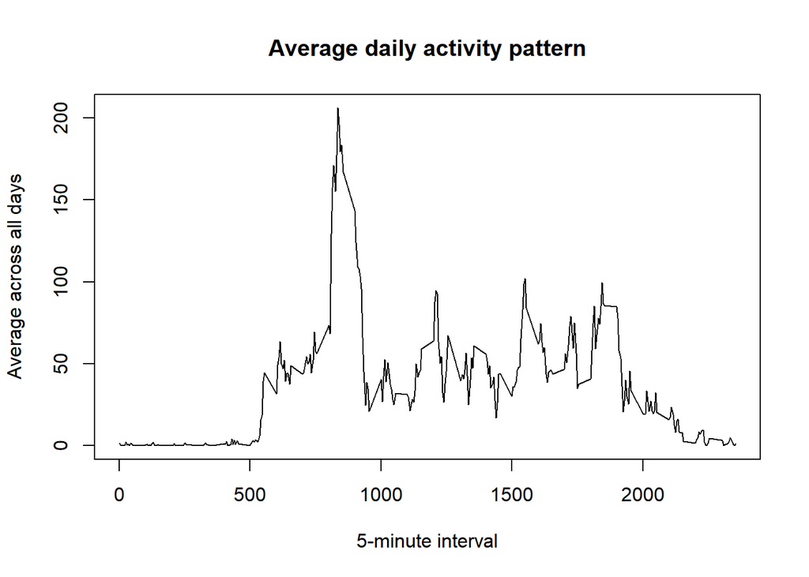

```r
#compute mean of steps by interval
StepsIntervalPerDays <- DSwithoutNA %>%
   group_by( interval) %>%
  select( steps,  interval) %>%
   summarise ( "Total steps" = mean( steps,na.rm = TRUE))

#plot interval vs mean
plot( x= StepsIntervalPerDays$interval, y=StepsIntervalPerDays$`Total steps`, type="l", xlab = "5-minute interval", ylab = "Average across all days", main = "Average daily activity pattern")
```

2. Which 5-minute interval, on average across all the days in the dataset, contains the maximum number of steps?

```r
#compute the interval having max no of steps
print( paste( "Interval on max number of steps - ", StepsIntervalPerDays[ StepsIntervalPerDays$`Total steps`== max( StepsIntervalPerDays$`Total steps`), 1]) , sep="")
```

```
## [1] "Interval on max number of steps -  835"
```

## Imputing missing values

Note that there are a number of days/intervals where there are missing values (coded as NA). The presence of missing days may introduce bias into some calculations or summaries of the data.

Calculate and report the total number of missing values in the dataset (i.e. the total number of rows with NAs) Devise a strategy for filling in all of the missing values in the dataset. The strategy does not need to be sophisticated. For example, you could use the mean/median for that day, or the mean for that 5-minute interval, etc. Create a new dataset that is equal to the original dataset but with the missing data filled in.

```r
# update NA value with the median of all days mean values. this will avoid any spikes or outliares

#new dataset to have imputed values
dataset02 <- dataset

#replace NA values with the median of all days mean
dataset02[ is.na( dataset02$steps),1] <- median( StepsIntervalPerDays$`Total steps`)
```

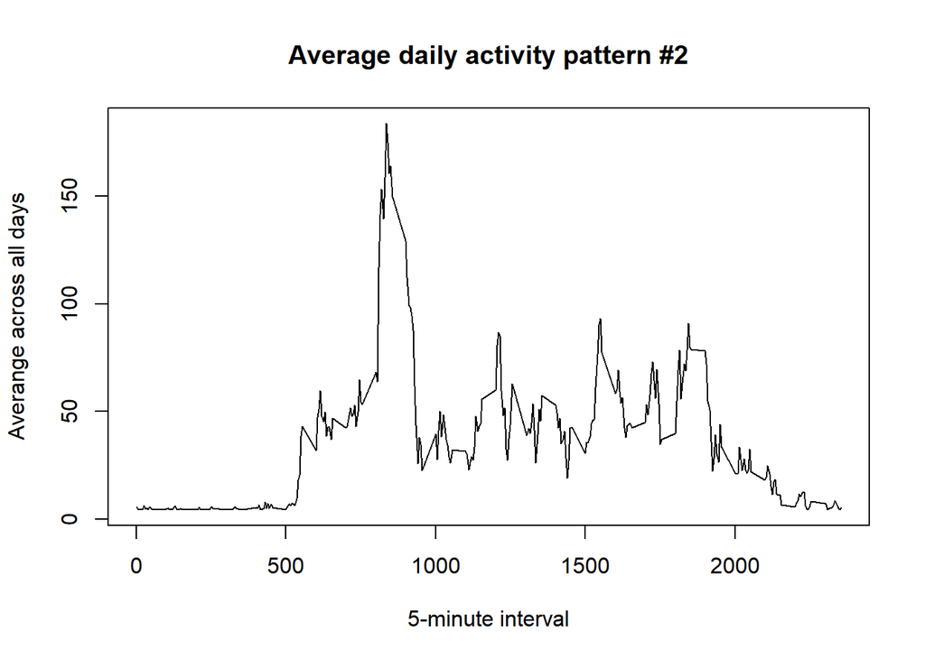

```r
#compute mean by interval post imputed data
StepsIntervalPerDays02 <- dataset02 %>%
   group_by( interval) %>%
   select( steps,  interval) %>%
   summarise ( "Total steps" = mean( steps,na.rm = TRUE))

#plot post imputed data
plot( x= StepsIntervalPerDays02$interval, y=StepsIntervalPerDays02$`Total steps`, type="l", xlab="5-minute interval", ylab= "Averange across all days", main="Average daily activity pattern #2")
```

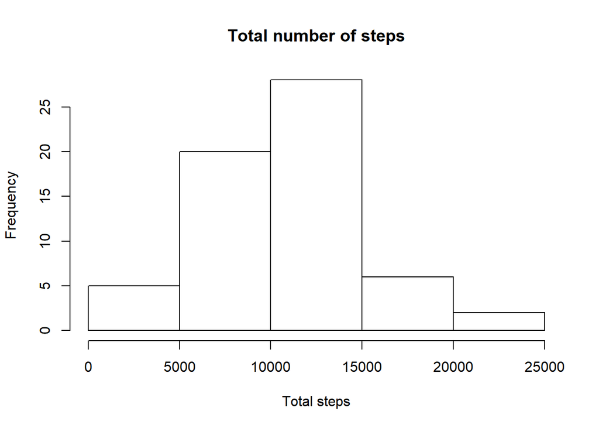

```r
#compute total after imputed values
TotalPerDays02 <- dataset02 %>%
   group_by( date) %>%
   select( steps, date) %>%
   summarise ( "Total steps" = sum( steps))

#plot histogram after imputated values
hist( TotalPerDays02$`Total steps`, xlab = "Total steps", main = "Total number of steps")
```

```r
#more observation
print( nrow( TotalPerDays02))
```

```
## [1] 61
```

## Are there differences in activity patterns between weekdays and weekends?

For this part the weekdays() function may be of some help here. Use the dataset with the filled-in missing values for this part.

Create a new factor variable in the dataset with two levels – “weekday” and “weekend” indicating whether a given date is a weekday or weekend day. Make a panel plot containing a time series plot (i.e. type=“l”) of the 5-minute interval (x-axis) and the average number of steps taken, averaged across all weekday days or weekend days (y-axis). See the README file in the GitHub repository to see an example of what this plot should look like using simulated data.

[figure not shown]

```r
#create new field weekdays
dataset02 <- mutate( dataset02, Wkdays=weekdays(dataset$date))

#separate dataset for weekends
WeekendDS <- dataset02 %>%
         filter( Wkdays %in% c("Saturday", "Sunday") ) %>%
         group_by( interval) %>%
         select( steps,  interval) %>%
         summarise ( "Total steps" = mean( steps,na.rm = TRUE))

#dataset for weekdays
WeekdaysDS <- dataset02 %>%
# should be flip of previous filter statement..unable to recall
   filter( Wkdays %in% c("Monday", "Tuesday", "Wednesday", "Thursday","Friday") ) %>%
   group_by( interval) %>%
   select( steps,  interval) %>%
   summarise ( "Total steps" = mean( steps,na.rm = TRUE))

#create panel to render two plots together

par( mfrow=c(2,1))
par(mar=c(0.1, 4.5, 1, 0.3))

plot( x= WeekendDS$interval, y=WeekendDS$`Total steps` , type="l", xlab= "", ylab="", main = "weekend",cex.axis=0.1, tck=-.005)

par(mar=c(4, 4.5,.8, 0.3))
plot( x= WeekdaysDS$interval, y=WeekdaysDS$`Total steps` , type="l", xlab= "Interval", ylab="Number of steps", main = "weekdays",cex.axis=0.8, tck=-.05)
```